# Community size maize roots

Thoenen_et_al_BX_tolerance

Lisa Thoenen

2023-09-08

### Background

We conducted this experiment to investigate wheater bacterial community size differs between plants producing different amounts of benzoxazinoids.

Plants were grown in Changins field soil for 6 weeks and fertilized. Maize and was grown in 1 L pots.

# CFU Plating experiments

## Greenhouse experiment 1

*Fig. S1A*

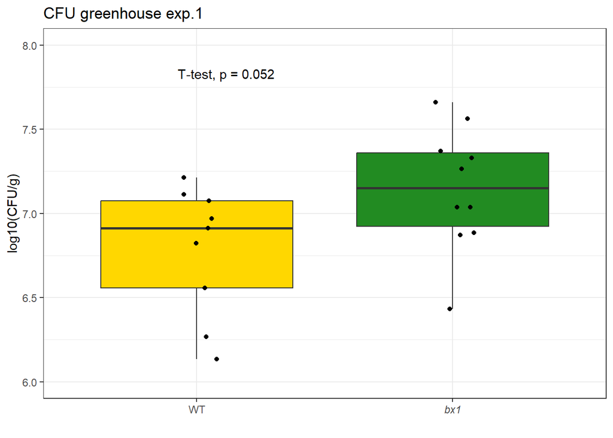

## Greenhouse experiment 2

| Var1 | Freq |
| --- | --- |
| WT.root | 10 |
| bx1.root | 10 |
| WT.rhizo | 0 |
| bx1.rhizo | 0 |
| WT.soil | 0 |
| bx1.soil | 0 |

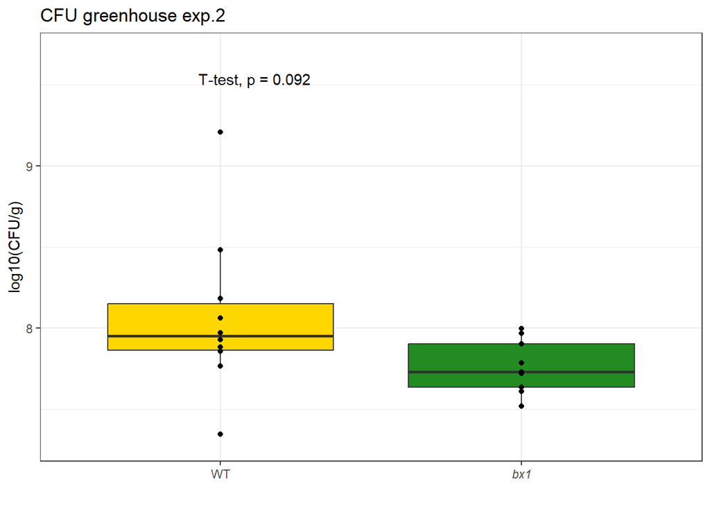

# qPCR

## Greenhouse experiments

**Normality**: If the Sig. value of the Shapiro-Wilk Test is greater than 0.05, the data is normal. If it is below 0.05, the data significantly deviate from a normal distribution.

```
##
##  Shapiro-Wilk normality test
##
## data:  qPCR_GH$RB
## W = 0.96896, p-value = 0.007814
```

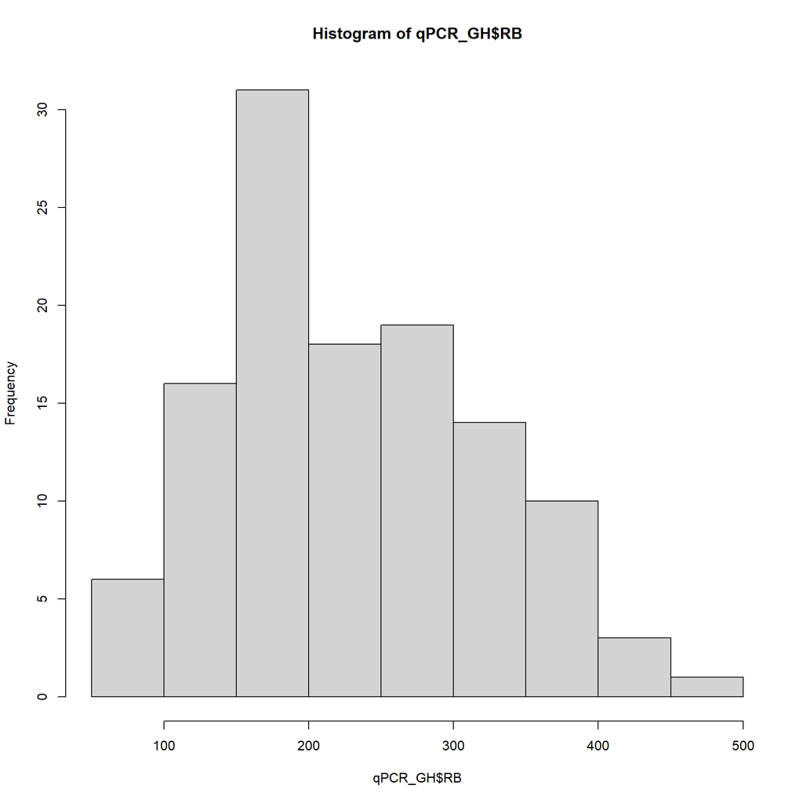

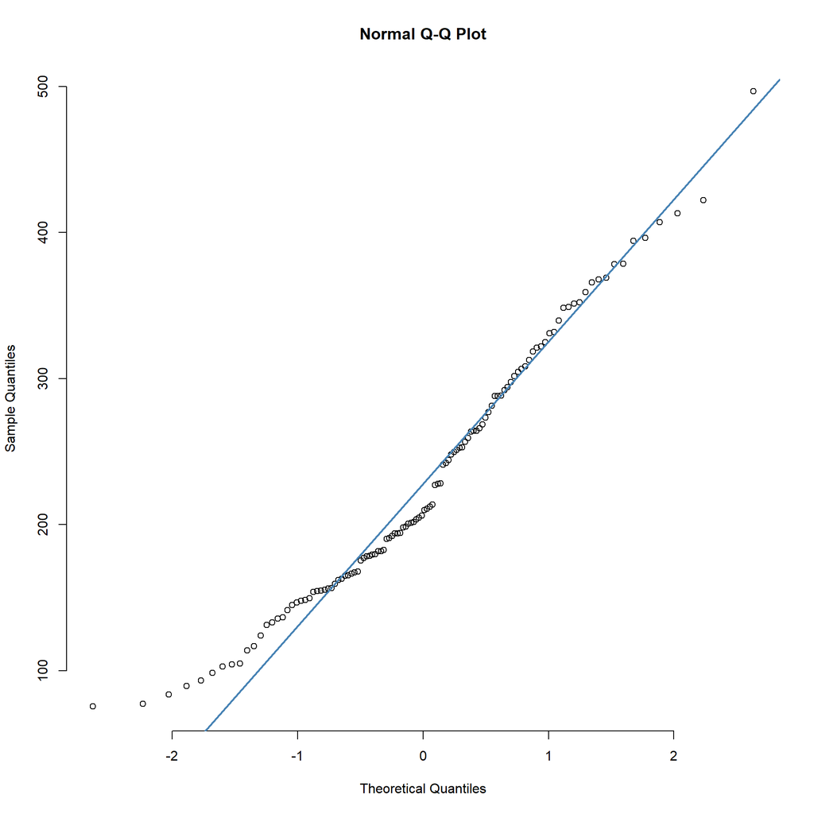

```
##
##  Shapiro-Wilk normality test
##
## data:  qPCR_GH$RBi
## W = 0.88587, p-value = 4.857e-08
```

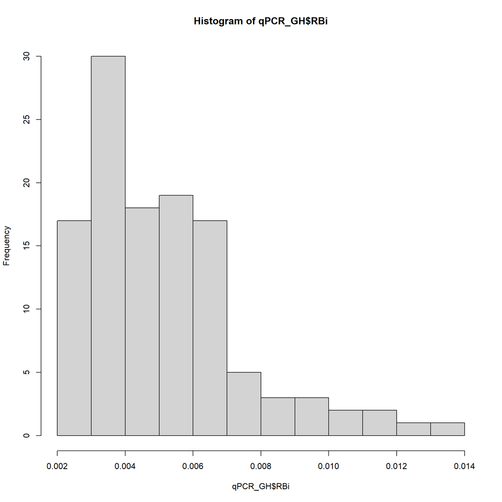

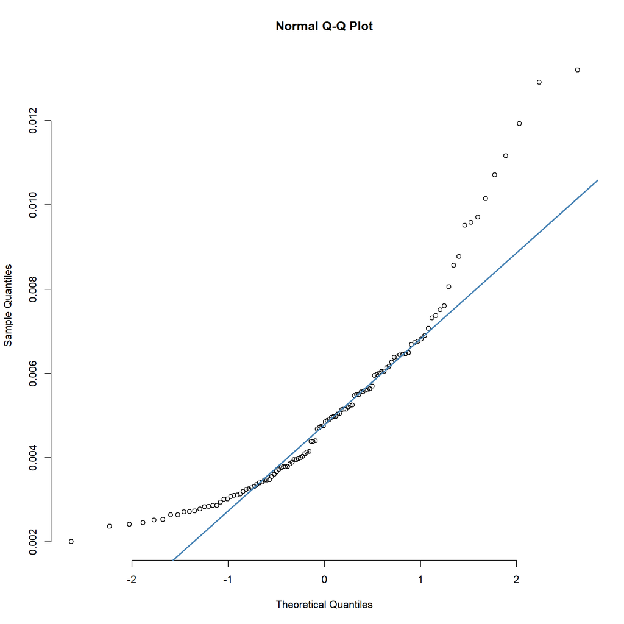

| Var1 | Freq |
| --- | --- |
| WT.root.Okt.1 | 9 |
| bx1.root.Okt.1 | 10 |
| WT.root.Sept.1 | 10 |
| bx1.root.Sept.1 | 10 |
| WT.root.Okt.2 | 10 |
| bx1.root.Okt.2 | 10 |
| WT.root.Sept.2 | 10 |
| bx1.root.Sept.2 | 10 |
| WT.root.Okt.3 | 9 |
| bx1.root.Okt.3 | 10 |
| WT.root.Sept.3 | 10 |
| bx1.root.Sept.3 | 10 |

*RB* E(plant gene) ^ Ct(plant gene) / E(16S) ^ Ct(16S)

Low value means more more bacteria!

*Fig. 6B Tolerance chapter* 180 * 220

Experiment 1 in september

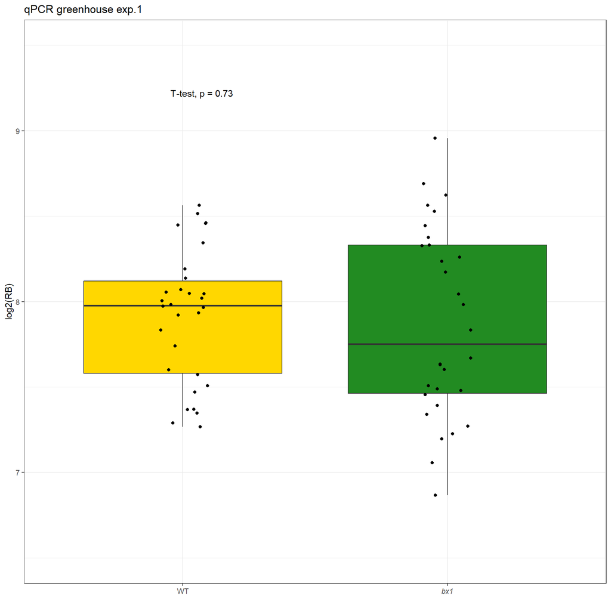

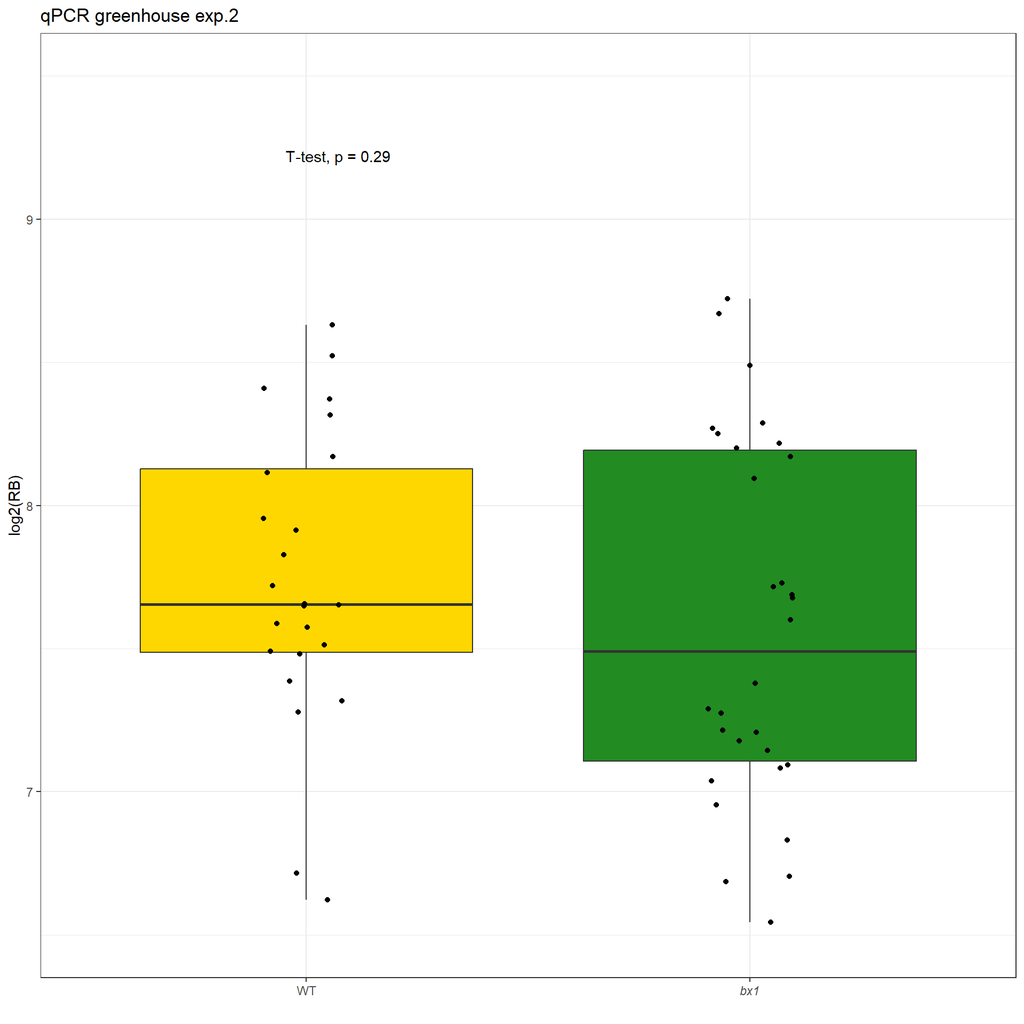

# Field experiments

**Normality**: If the Sig. value of the Shapiro-Wilk Test is greater than 0.05, the data is normal. If it is below 0.05, the data significantly deviate from a normal distribution.

this dataset is not normally distributed for the RB value

```
##
##  Shapiro-Wilk normality test
##
## data:  qPCR_field$RB
## W = 0.6914, p-value < 2.2e-16
```

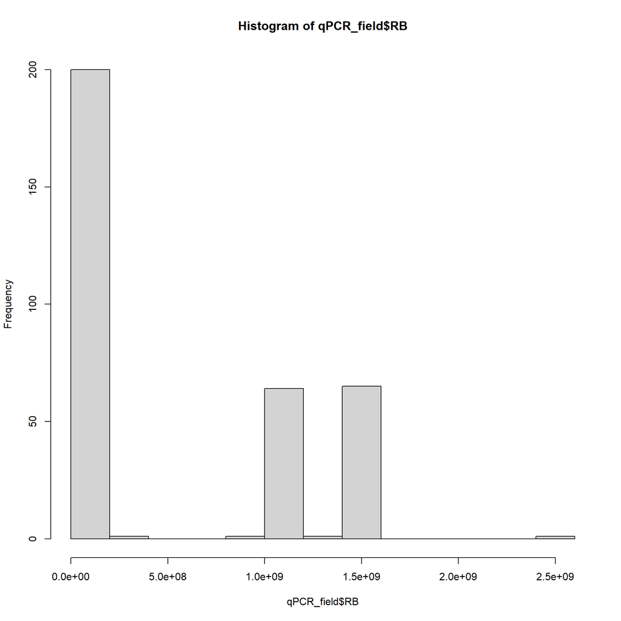

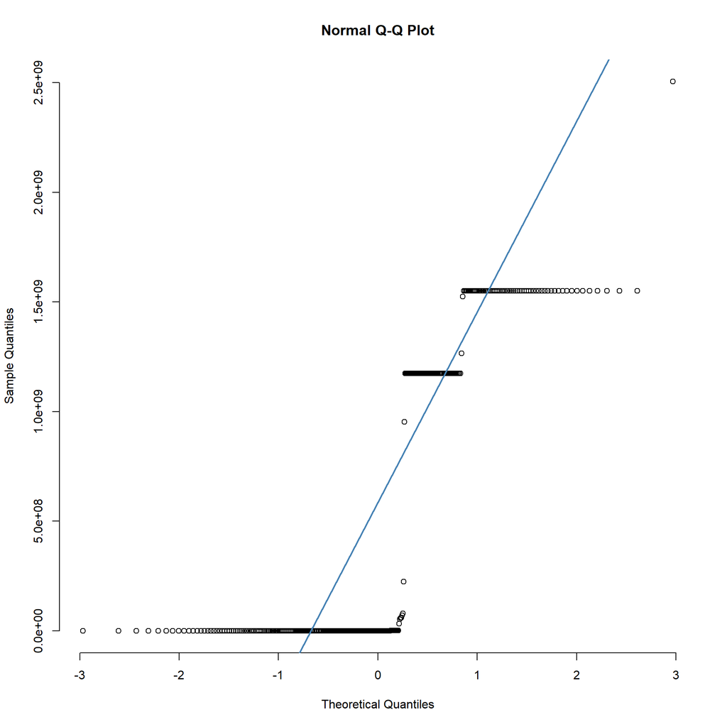

removing a wired sample

*Fig. S1C* 180 * 220

log2(RB): without outliers filtering for Cq.799F904R > 10

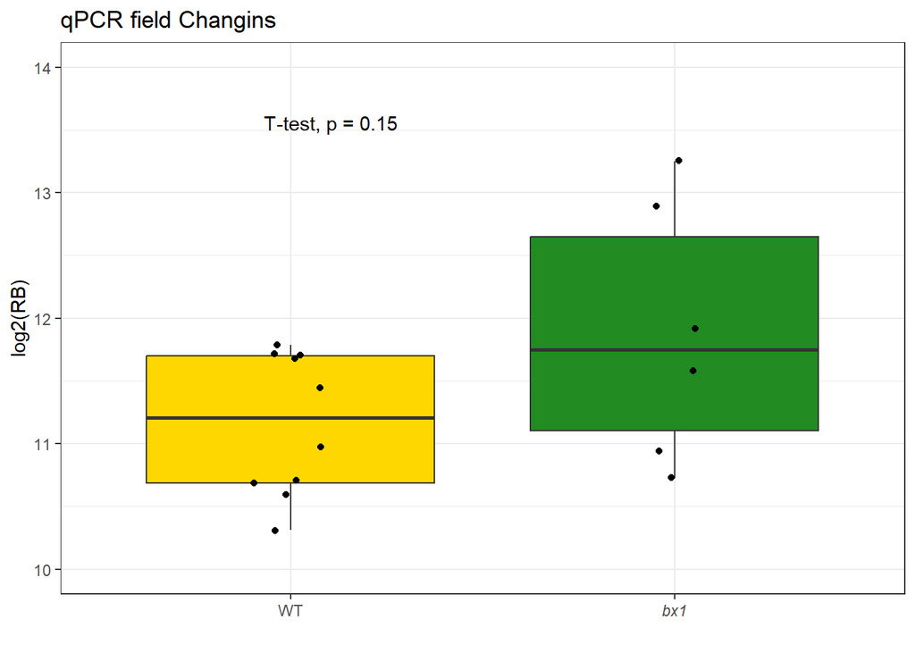

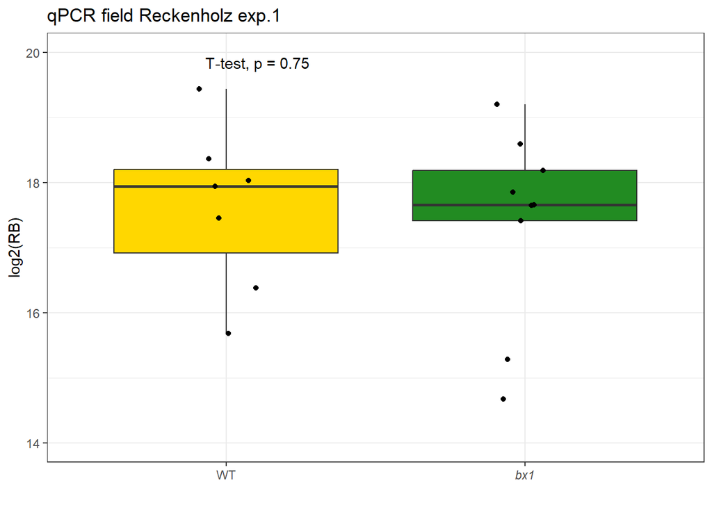

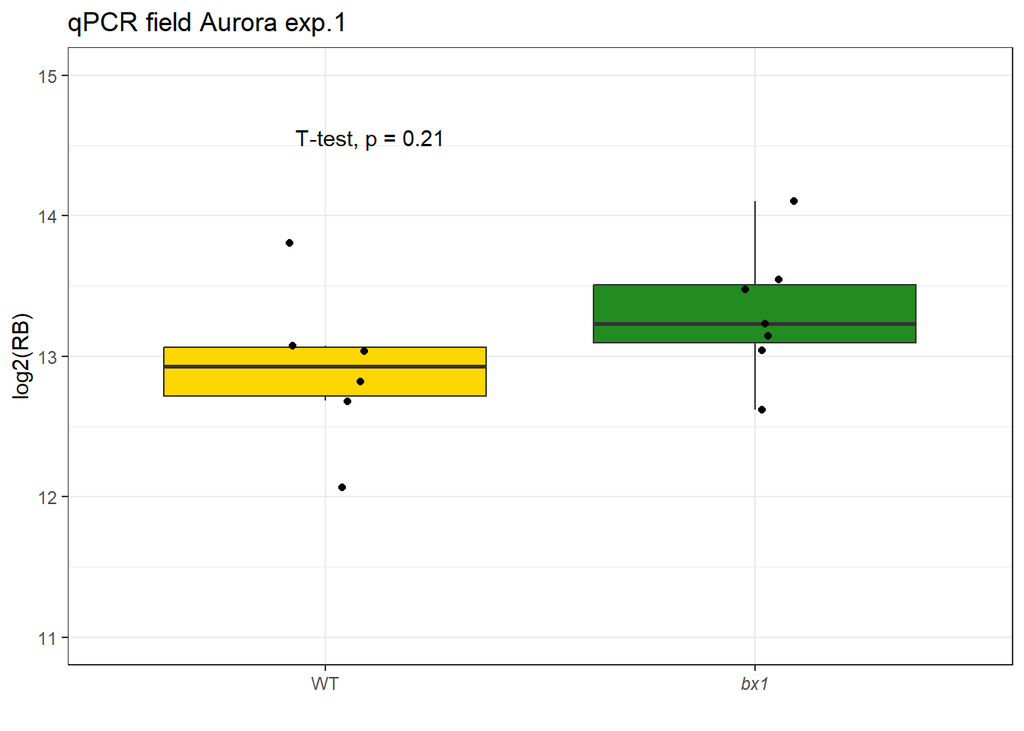